# Tugas Besar IF2220 Probabilitas dan Statistika

Penarikan Kesimpulan dan Pengujian Hipotesis

## Kelompok 30 K2

- Yanuar Sano Nur Rasyid (13521110)
- Febryan Arota Hia (13521120)

```python
import pandas as pd
import numpy as np
import matplotlib.pyplot as plt
from IPython.display import display, Markdown
```

#### 1. Menuliskan deskripsi statistika (descriptive statistics) dari semua kolom pada data yang bersifat numerik, terdiri dari mean, median, modus, standar deviasi, variansi, range, nilai minimum, maksimum, kuartil, IQR (interquartile range), skewness, dan kurtosis. Boleh juga ditambahkan deskripsi lain.

```python
df = pd.read_csv('dataset/anggur.csv')
df.info()
```

```
<class 'pandas.core.frame.DataFrame'>
RangeIndex: 1000 entries, 0 to 999
Data columns (total 12 columns):
 #   Column                Non-Null Count  Dtype
---  ------                --------------  -----
 0   fixed acidity         1000 non-null   float64
 1   volatile acidity      1000 non-null   float64
 2   citric acid           1000 non-null   float64
 3   residual sugar        1000 non-null   float64
 4   chlorides             1000 non-null   float64
 5   free sulfur dioxide   1000 non-null   float64
 6   total sulfur dioxide  1000 non-null   float64
 7   density               1000 non-null   float64
 8   pH                    1000 non-null   float64
 9   sulphates             1000 non-null   float64
 10  alcohol               1000 non-null   float64
 11  quality               1000 non-null   int64
dtypes: float64(11), int64(1)
memory usage: 93.9 KB
```

```python
desc = pd.DataFrame()
desc["Mean"] = df.mean()
desc["Median"] = df.median()
desc["Modus"] = df.mode().iloc[0]
desc["Std"] = df.std()
desc["Min"] = df.min()
desc["Max"] = df.max()
desc["Range"] = df.max() - df.min()
desc["Q1"] = df.quantile(0.25)
desc["Q2"] = df.quantile(0.5)
desc["Q3"] = df.quantile(0.75)
desc["IQR"] = desc["Q3"] - desc["Q1"]
desc["Skewness"] = df.skew()
desc["Kurtosis"] = df.kurtosis()
desc["Missing"] = df.isnull().sum()
desc["Unique"] = df.nunique()
desc
```

|  | Mean | Median | Modus | Std | Min | Max | Range | Q1 | Q2 | Q3 | IQR | Skewness | Kurtosis | Missing | Unique |
| --- | --- | --- | --- | --- | --- | --- | --- | --- | --- | --- | --- | --- | --- | --- | --- |
| fixed acidity | 7.152530 | 7.150000 | 6.540000 | 1.201598 | 3.320000 | 11.490000 | 8.170000 | 6.377500 | 7.150000 | 8.000000 | 1.622500 | -0.028879 | -0.019292 | 0 | 417 |
| volatile acidity | 0.520839 | 0.524850 | 0.554600 | 0.095848 | 0.139900 | 0.805100 | 0.665200 | 0.456100 | 0.524850 | 0.585375 | 0.129275 | -0.197699 | 0.161853 | 0 | 879 |
| citric acid | 0.270517 | 0.272200 | 0.301900 | 0.049098 | 0.116700 | 0.409600 | 0.292900 | 0.237800 | 0.272200 | 0.302325 | 0.064525 | -0.045576 | -0.104679 | 0 | 769 |
| residual sugar | 2.567104 | 2.519430 | 0.032555 | 0.987915 | 0.032555 | 5.550755 | 5.518200 | 1.896330 | 2.519430 | 3.220873 | 1.324544 | 0.132638 | -0.042980 | 0 | 1000 |
| chlorides | 0.081195 | 0.082167 | 0.015122 | 0.020111 | 0.015122 | 0.140758 | 0.125635 | 0.066574 | 0.082167 | 0.095312 | 0.028738 | -0.051319 | -0.246508 | 0 | 1000 |
| free sulfur dioxide | 14.907679 | 14.860346 | 0.194679 | 4.888100 | 0.194679 | 27.462525 | 27.267847 | 11.426717 | 14.860346 | 18.313098 | 6.886381 | 0.007130 | -0.364964 | 0 | 1000 |
| total sulfur dioxide | 40.290150 | 40.190000 | 35.200000 | 9.965767 | 3.150000 | 69.960000 | 66.810000 | 33.785000 | 40.190000 | 47.022500 | 13.237500 | -0.024060 | 0.063950 | 0 | 881 |
| density | 0.995925 | 0.996000 | 0.995900 | 0.002020 | 0.988800 | 1.002600 | 0.013800 | 0.994600 | 0.996000 | 0.997200 | 0.002600 | -0.076883 | 0.016366 | 0 | 107 |
| pH | 3.303610 | 3.300000 | 3.340000 | 0.104875 | 2.970000 | 3.710000 | 0.740000 | 3.230000 | 3.300000 | 3.370000 | 0.140000 | 0.147673 | 0.080910 | 0 | 61 |
| sulphates | 0.598390 | 0.595000 | 0.590000 | 0.100819 | 0.290000 | 0.960000 | 0.670000 | 0.530000 | 0.595000 | 0.670000 | 0.140000 | 0.149199 | 0.064819 | 0 | 60 |
| alcohol | 10.592280 | 10.610000 | 9.860000 | 1.510706 | 6.030000 | 15.020000 | 8.990000 | 9.560000 | 10.610000 | 11.622500 | 2.062500 | -0.018991 | -0.131732 | 0 | 490 |
| quality | 7.958000 | 8.000000 | 8.000000 | 0.902802 | 5.000000 | 10.000000 | 5.000000 | 7.000000 | 8.000000 | 9.000000 | 2.000000 | -0.089054 | 0.108291 | 0 | 6 |

2. Membuat Visualisasi plot distribusi, dalam bentuk histogram dan boxplot untuk setiap

kolom numerik. Berikan uraian penjelasan kondisi setiap kolom berdasarkan kedua plot tersebut.

```python
# code no 2
def plot_distribusi(data, title):
    fig, ax = plt.subplots(1, 2, figsize=(15, 5))
    fig.suptitle(title)
    ax[0].hist(data, bins=20)
    ax[1].boxplot(data)
    ax[0].set_title("Histogram " + title.lower())
    ax[1].set_title("Boxplot " + title.lower())
    plt.show()
```

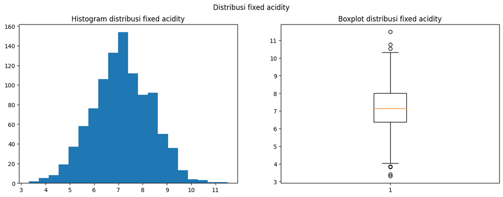

```python
plot_distribusi(df["fixed acidity"], "Distribusi fixed acidity")
```

Visualisasi data pada kolom fixed acidity dengan histogram dan boxplot menunjukkan bahwa data berbentuk simetris dan terdapat beberapa outlier yang nilainya melebihi maksimum dan kurang dari minimum

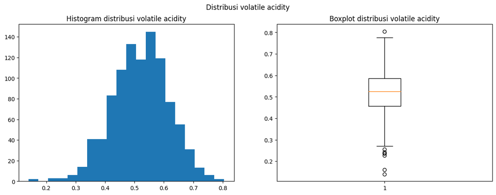

```python
plot_distribusi(df["volatile acidity"], "Distribusi volatile acidity")
```

Visualisasi data pada kolom volatile acidity dengan histogram dan boxplot menunjukkan bahwa data sedikit berbentuk left-skewed (negative skew) dan terdapat beberapa outlier pada maksimum dan minimum dengan jumlah yang lebih banyak kurang dari minimum.

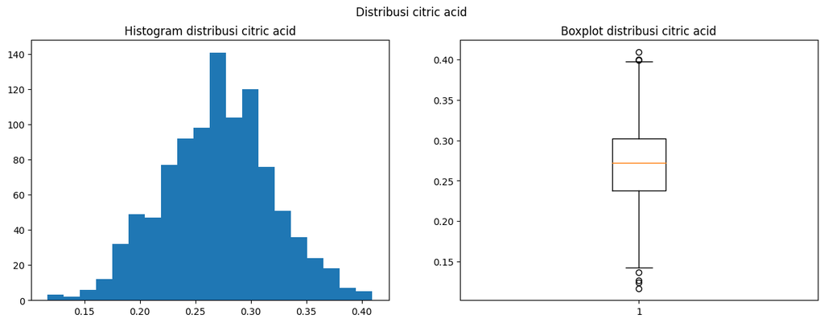

```python
plot_distribusi(df["citric acid"], "Distribusi citric acid")
```

Visualisasi data pada kolom citric acid dengan histogram dan boxplot menunjukkan bahwa data berbentuk simetris dan terdapat beberapa outlier pada maksimum dan minimum dengan jumlah yang lebih banyak kurang dari minimum.

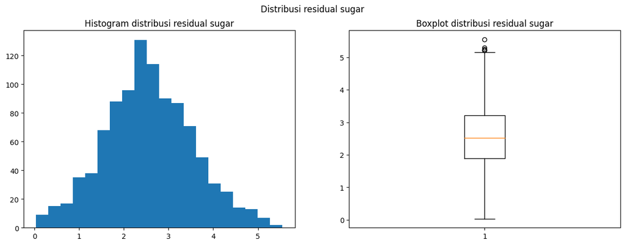

```python
plot_distribusi(df["residual sugar"], "Distribusi residual sugar")
```

Visualisasi data pada kolom residual sugar dengan histogram dan boxplot menunjukkan bahwa data sedikit berbentuk right-skewed (positive skew) dan terdapat beberapa outlier yang melebihi nilai maksimum.

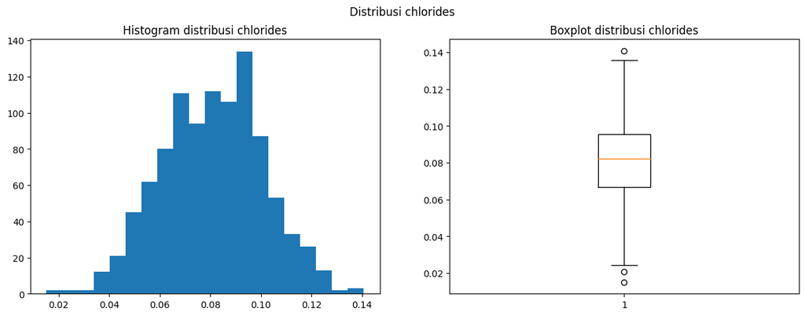

```python
plot_distribusi(df["chlorides"], "Distribusi chlorides")
```

Visualisasi data pada kolom chlorides dengan histogram dan boxplot menunjukkan bahwa data sedikit berbentuk left-skewed (negative skew) dan terdapat beberapa outlier pada maksimum dan minimum dengan jumlah yang lebih banyak kurang dari minimum.

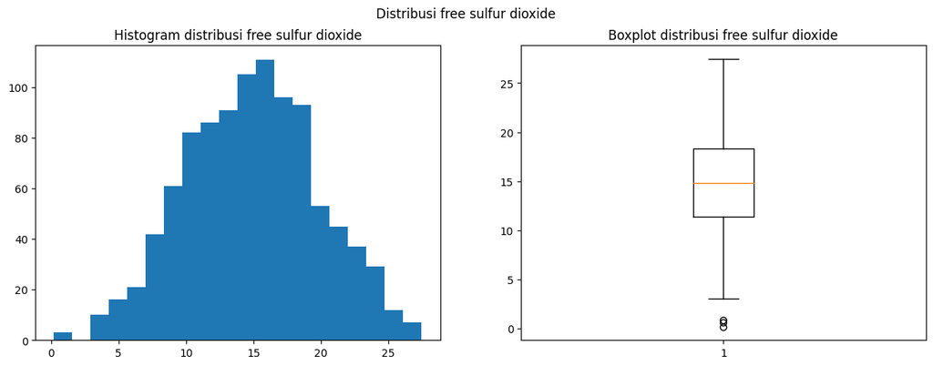

```python
plot_distribusi(df["free sulfur dioxide"], "Distribusi free sulfur dioxide")
```

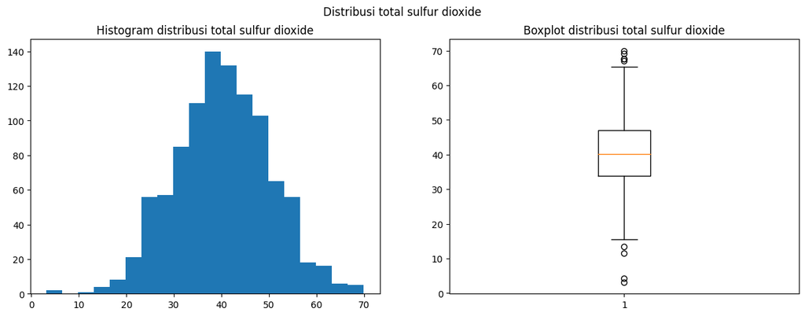

```python
plot_distribusi(df["total sulfur dioxide"], "Distribusi total sulfur dioxide")
```

Visualisasi data pada kolom total sulfur dioxide dengan histogram dan boxplot menunjukkan bahwa data berbentuk simetris dan terdapat beberapa outlier pada maksimum dan minimum dengan jumlah yang lebih banyak lebih besar dari maksimum.

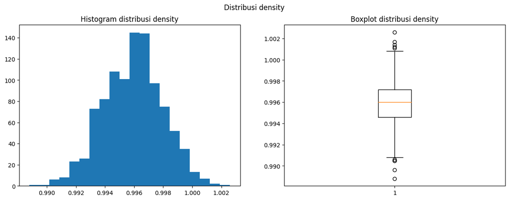

```python
plot_distribusi(df["density"], "Distribusi density")
```

Visualisasi data pada kolom density dengan histogram dan boxplot menunjukkan bahwa data berbentuk simetris dan terdapat beberapa outlier yang melebihi maksimum dan kurang dari minimum dengan outlier maksimum lebih banyak.

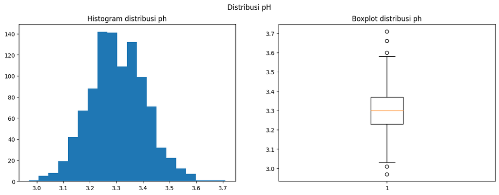

```python
plot_distribusi(df["pH"], "Distribusi pH")
```

Visualisasi data pada kolom pH dengan histogram dan boxplot menunjukkan bahwa data sedikit berbentuk right-skewed (positive skew) dan terdapat beberapa outlier pada maksimum dan minimum dengan jumlah yang lebih banyak lebih besar dari maksimum.

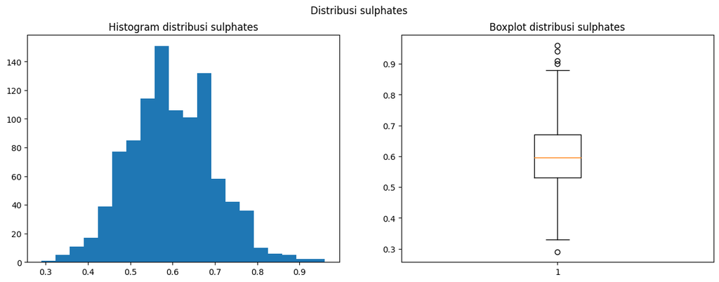

```python
plot_distribusi(df["sulphates"], "Distribusi sulphates")
```

Visualisasi data pada kolom sulphates dengan histogram dan boxplot menunjukkan bahwa data sedikit berbentuk right-skewed (positive skew) dan terdapat beberapa outlier pada maksimum dan minimum dengan jumlah yang lebih banyak lebih besar dari maksimum.

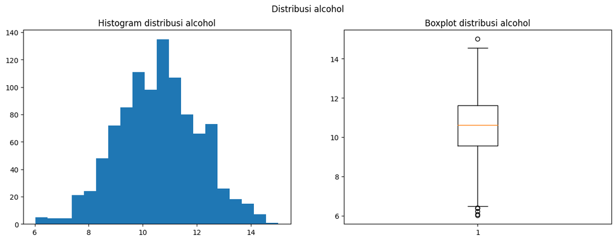

```python
plot_distribusi(df["alcohol"], "Distribusi alcohol")
```

Visualisasi data pada kolom alcohol dengan histogram dan boxplot menunjukkan bahwa data berbentuk simetris dan terdapat beberapa outlier pada maksimum dan minimum dengan jumlah yang lebih banyak kurang dari minimum.

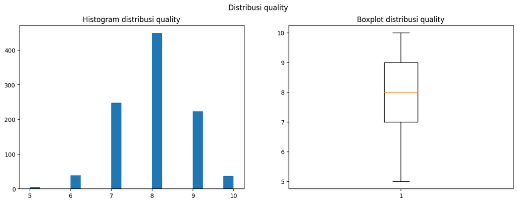

```python
plot_distribusi(df["quality"], "Distribusi quality")
```

Visualisasi data pada kolom quality dengan histogram dan boxplot menunjukkan bahwa data berbentuk simetris dan tidak terdapat outlier yang ditunjukkan oleh boxplot.

#### 3. Menentukan setiap kolom numerik berdistribusi normal atau tidak. Gunakan normality test yang dikaitkan dengan histogram plot.

```python
import scipy.stats as st
```

```python
def normalityTest(data):
    k, p = st.normaltest(data)
    alpha = 0.05
    if p < alpha:
        print(f"p = {round(p,4)}, sehingga data tidak terdistribusi dengan normal")
    else:
        print(f"p = {round(p,4)}, sehingga data terdistribusi dengan normal")
    mean,std=st.norm.fit(data)
    plt.hist(data, bins='auto', density=True)
    xmin, xmax = plt.xlim()
    x = np.linspace(xmin, xmax, 100)
    y = st.norm.pdf(x, mean, std)
    plt.plot(x, y,'k',lw=1)
```

```
p = 0.9309, sehingga data terdistribusi dengan normal
```

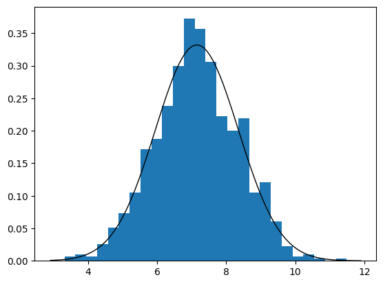

```python
normalityTest(df["fixed acidity"])
```

```
p = 0.0226, sehingga data tidak terdistribusi dengan normal
```

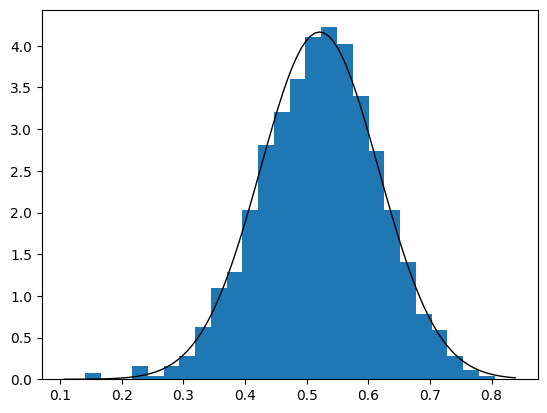

```python
normalityTest(df["volatile acidity"])
```

```
p = 0.6817, sehingga data terdistribusi dengan normal
```

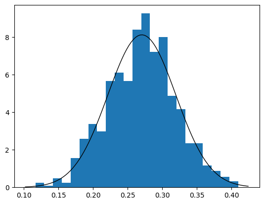

```python
normalityTest(df["citric acid"])
```

```
p = 0.2247, sehingga data terdistribusi dengan normal
```

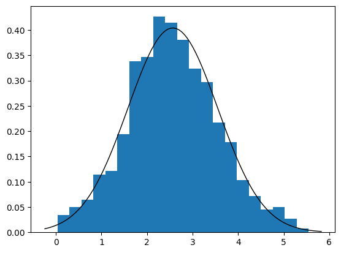

```python
normalityTest(df["residual sugar"])
```

```
p = 0.1705, sehingga data terdistribusi dengan normal
```

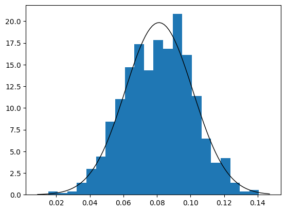

```python
normalityTest(df["chlorides"])
```

```
p = 0.0174, sehingga data tidak terdistribusi dengan normal
```

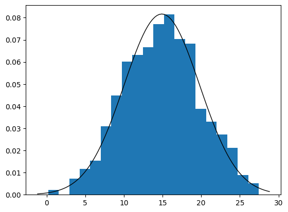

```python
normalityTest(df["free sulfur dioxide"])
```

```
p = 0.8489, sehingga data terdistribusi dengan normal
```

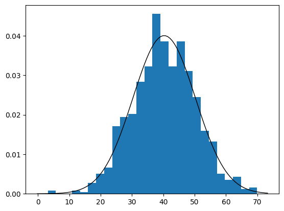

```python
normalityTest(df["total sulfur dioxide"])
```

```
p = 0.5985, sehingga data terdistribusi dengan normal
```

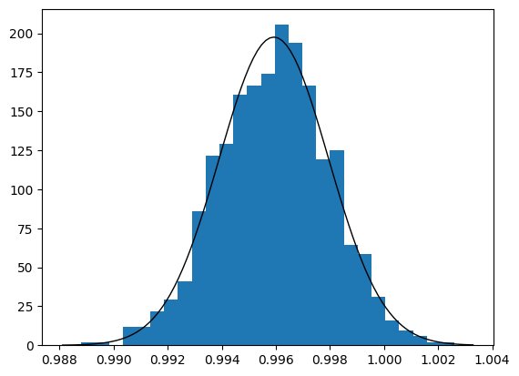

```python
normalityTest(df["density"])
```

```
p = 0.1368, sehingga data terdistribusi dengan normal
```

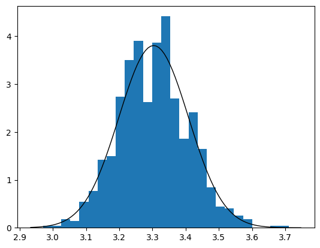

```python
normalityTest(df["pH"])
```

```
p = 0.1388, sehingga data terdistribusi dengan normal
```

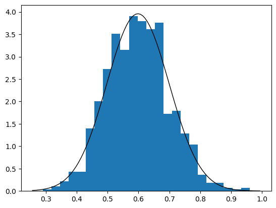

```python
normalityTest(df["sulphates"])
```

```
p = 0.6791, sehingga data terdistribusi dengan normal
```

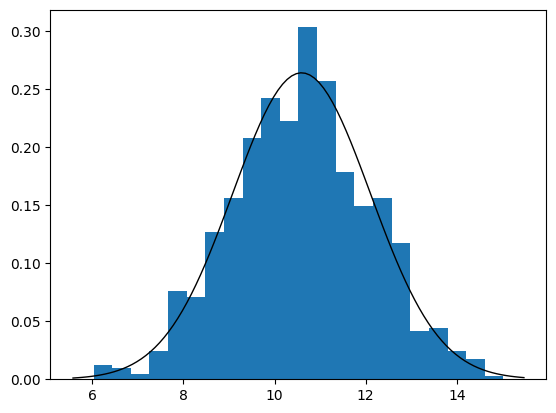

```python
normalityTest(df["alcohol"])
```

```
p = 0.3888, sehingga data terdistribusi dengan normal
```

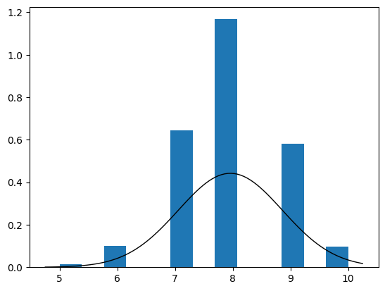

```python
normalityTest(df["quality"])
```

##### 4. Melakukan test hipotesis 1 sampel

```python
from statsmodels.stats.weightstats import ztest
from statsmodels.stats.proportion import proportions_ztest
```

##### 4.a Nilai rata-rata pH di atas 3.29

1. $H_0$: $μ = 3.29$

2. $H_1$: $μ > 3.29$

3. $\alpha = 0.05$

4. Uji Statistik: $ z =\frac{\bar{x_{}} - μ_{0}} {\sigma/\sqrt{n}} $

Daerah kritis: $z > z_\alpha$

Jika $z$ berada pada *critical section* ($z > z_\alpha$), maka nilai $p < \alpha$ dan $H_0$ ditolak

Jika $z$ tidak berada pada *critical section* ($z ≤ z_\alpha$), maka nilai $p ≥ \alpha$ dan $H_0$ diterima

5. Komputasi  
   $n = 1000$  
   $\bar x$ = $3.3036$  
   $\sigma $ = $0.1049$  
   $z = 4.1038$  
   $z_\alpha$ = $1.6449$  
   $p = 2.03e-05$

6. Test daerah kritis:

Keputusan: Tolak $H_0$ karena $z > z_\alpha$

Tes Signifikan: Tolak $H_0$ karena $p$ lebih kecil dari tingkat signifikan ($p < 0.05$)

Maka, nilai rata-rata pH lebih dari $3.29$

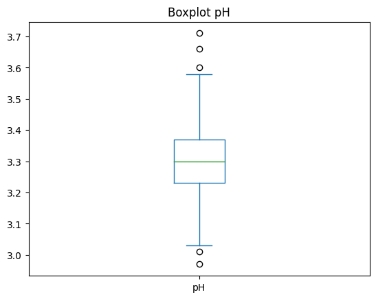

```python
alpha = 0.05
pH = df["pH"]

# Uji statistik single sample right tailed Z-test
x_bar = pH.mean()
miu_0 = 3.29
std = pH.std()
n = len(pH)
root_n = np.sqrt(len(pH))
z_alpha = st.norm.ppf(1 - alpha)
z = (x_bar - miu_0) / (std / root_n)
p_value = 1-st.norm.cdf(z)

display(Markdown(f"1. $H_0$:  $μ = {miu_0}$"))
display(Markdown(f"2. $H_1$:  $μ > {miu_0}$"))
display(Markdown(f"3. $\\alpha = 0.05$"))
display(Markdown("4. Uji Statistik:  $ z =\\frac{\\bar{x_{}} - μ_{0}} {\\sigma/\\sqrt{n}} $"))
display(Markdown(f"Daerah kritis: $z > z_\\alpha$"))
display(Markdown(f"Jika $z$ berada pada *critical section* ($z > z_\\alpha$), maka nilai $p < \\alpha$ dan $H_0$ ditolak"))
display(Markdown(f"Jika $z$ tidak berada pada *critical section* ($z ≤ z_\\alpha$), maka nilai $p ≥ \\alpha$ dan $H_0$ diterima"))

display(Markdown(f"5. Komputasi<br>  $n = {n}$ <br>$\\bar x$ = ${round(x_bar, 4)}$ <br> $\\sigma $ = ${round(std, 4)}$<br> $z = {round(z, 4)}$<br> $z_\\alpha$ = ${round(z_alpha, 4)}$<br> $p = {round(p_value, 7)}$<br> "))
display(Markdown(f"6. Test daerah kritis: "))
if z > z_alpha:
    display(Markdown(f"Keputusan: Tolak $H_0$ karena $z > z_\\alpha$"))
    display(Markdown(f"Tes Signifikan: Tolak $H_0$ karena $p$ lebih kecil dari tingkat signifikan ($p < {alpha}$)"))
    display(Markdown(f"Maka, nilai rata-rata pH lebih dari ${miu_0}$"))
else:
    display(Markdown(f"Keputusan: Tidak menolak $H_0$ karena ]$z ≤ z_\\alpha$" ))
    display(Markdown(f"Tes Signifikan: Terima $H_0$ dikarenakan $p$ lebih besar atau sama dengan tingkat signifikan ($p ≥ {alpha}$)"))
    display(Markdown(f"Maka, nilai rata-rata pH sama dengan ${miu_0}$"))

df["pH"].plot(kind="box")
plt.title("Boxplot pH")
plt.show()
```

##### 4.b Nilai rata-rata Residual Sugar tidak sama dengan 2.50?

1. $H_0$: $μ = 2.5$

2. $H_1$: $μ ≠ 2.5$

3. $\alpha = 0.05$

4. Uji Statistik: $ z =\frac{\bar{x_{}} - μ_{0}} {\sigma/\sqrt{n}} $

Daerah kritis: $z_{\alpha/2}$ atau $z < -z_{\alpha/2}$

Jika $z$ berada pada *critical section* ( $z_{\alpha/2}$ atau $z < -z_{\alpha/2}$), maka nilai $p < \alpha$ dan $H_0$ ditolak

Jika $z$ tidak berada pada *critical section*, maka nilai $p ≥ \alpha$ dan $H_0$ diterima

5. Komputasi  
   $n = 1000$  
   $\bar x$ = $2.5671$  
   $\sigma $ = $0.9879$  
   $z = 2.148$  
   $z\alpha/2$ = $1.96$  
   $p = 0.0317$

6. Test daerah kritis:

Keputusan: Tolak $H_0$ karena $z > z_{\alpha/2}$

Tes Signifikan: Tolak $H_0$ karena $p$ lebih kecil dari tingkat signifikan ($p < 0.05$)

Maka, nilai rata-rata residual sugar tidak sama dengan $2.5$

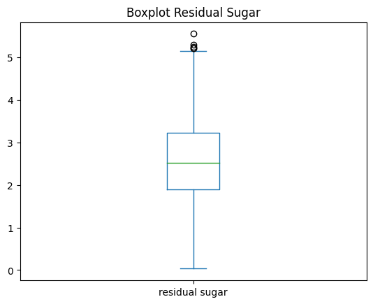

```python
data = df["residual sugar"]

# Uji statistik single sample two tailed Z-test
miu_0 = 2.50
alpha = 0.05
x_bar = data.mean()
std = data.std()
n = len(data)
root_n = np.sqrt(len(data))
z_alpha = st.norm.ppf(1 - alpha /2)
z = (x_bar - miu_0) / (std / root_n)
p_value = 1-abs(st.norm.cdf(z)-st.norm.cdf(-1*z))

display(Markdown(f"1. $H_0$:   $μ = {miu_0}$"))
display(Markdown(f"2. $H_1$:   $μ ≠ {miu_0}$"))
display(Markdown(f"3. $\\alpha = 0.05$"))
display(Markdown("4. Uji Statistik:  $ z =\\frac{\\bar{x_{}} - μ_{0}} {\\sigma/\\sqrt{n}} $"))
display(Markdown("Daerah kritis: $z_{\\alpha/2}$ atau $z < -z_{\\alpha/2}$"))
display(Markdown("Jika $z$ berada pada *critical section* ( $z_{\\alpha/2}$ atau $z < -z_{\\alpha/2}$), maka nilai $p < \\alpha$ dan $H_0$ ditolak"))
display(Markdown(f"Jika $z$ tidak berada pada *critical section*, maka nilai $p ≥ \\alpha$ dan $H_0$ diterima"))

display(Markdown(f"5. Komputasi<br>  $n = {n}$ <br>$\\bar x$ = ${round(x_bar, 4)}$ <br> $\\sigma $ = ${round(std, 4)}$<br> $z = {round(z, 4)}$<br> $z\\alpha/2$ = ${round(z_alpha, 4)}$<br> $p = {round(p_value, 4)}$<br> "))
display(Markdown(f"6. Test daerah kritis: "))


if z < -z_alpha or z > z_alpha:
    display(Markdown("Keputusan: Tolak $H_0$ karena $z > z_{\\alpha/2}$"))
    display(Markdown(f"Tes Signifikan: Tolak $H_0$ karena $p$ lebih kecil dari tingkat signifikan ($p < {alpha}$)"))
    display(Markdown(f"Maka, nilai rata-rata residual sugar tidak sama dengan ${miu_0}$"))
else:
    display(Markdown("Keputusan: Tidak menolak $H_0$ karena $-z_{\\alpha/2} < z < z_{\\alpha/2}$" ))
    display(Markdown(f"Tes Signifikan: Tidak menolak $H_0$ dikarenakan $p$ lebih besar atau sama dengan tingkat signifikan ($p ≥ {alpha}$)"))
    display(Markdown(f"Maka, nilai rata-rata residual sugar sama dengan ${miu_0}$"))

data.plot(kind="box")
plt.title("Boxplot Residual Sugar")
plt.show()
```

##### 4.c Nilai rata-rata 150 baris pertama kolom sulphates bukan 0.65?

1. $H_0$: $μ = 0.65$

2. $H_1$: $μ ≠ 0.65$

3. $\alpha = 0.05$

4. Uji Statistik: $ z =\frac{\bar{x_{}} - μ_{0}} {\sigma/\sqrt{n}} $

Daerah kritis: $z > z_{\alpha/2}$ atau $z < -z_{\alpha/2}$

Jika $z$ berada pada *critical section* ( z_{\alpha/2}$ atau $z < -z_{\alpha/2}), maka nilai $p < \alpha$ dan $H_0$ ditolak

Jika $z$ tidak berada pada *critical section*, maka nilai $p ≥ \alpha$ dan $H_0$ diterima

5. Komputasi  
   $n = 150$  
   $\bar x$ = $0.6059$  
   $\sigma $ = $0.1089$  
   $z = -4.9648$  
   $z\alpha/2$ = $1.96$  
   $p = 6.875652918125752e-07$

6. Test daerah kritis:

Keputusan: Tolak $H_0$ karena $z < -z_{\alpha/2}$

Tes Signifikan: Tolak $H_0$ karena $p$ lebih kecil dari tingkat signifikan ($p < 0.05$)

Maka, nilai rata-rata 150 baris pertama kolom sulphates tidak sama dengan $0.65$

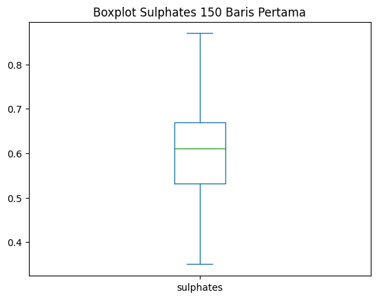

```python
data = df["sulphates"].head(150)

# Uji statistik single sample two tailed Z-test
miu_0 = 0.65
alpha = 0.05
x_bar = data.mean()
std = data.std()
n = len(data)
root_n = np.sqrt(len(data))
z_alpha = st.norm.ppf(1 - alpha /2)
z = (x_bar - miu_0) / (std / root_n)
p_value = 1-abs(st.norm.cdf(z)-st.norm.cdf(-1*z))

display(Markdown(f"1. $H_0$:  $μ = {miu_0}$"))
display(Markdown(f"2. $H_1$:  $μ ≠ {miu_0}$"))
display(Markdown(f"3. $\\alpha = 0.05$"))
display(Markdown("4. Uji Statistik:  $ z =\\frac{\\bar{x_{}} - μ_{0}} {\\sigma/\\sqrt{n}} $"))
display(Markdown("Daerah kritis: $z > z_{\\alpha/2}$ atau $z < -z_{\\alpha/2}$"))
display(Markdown("Jika $z$ berada pada *critical section* ( z_{\\alpha/2}$ atau $z < -z_{\\alpha/2}), maka nilai $p < \\alpha$ dan $H_0$ ditolak"))
display(Markdown(f"Jika $z$ tidak berada pada *critical section*, maka nilai $p ≥ \\alpha$ dan $H_0$ diterima"))

display(Markdown(f"5. Komputasi<br>  $n = {n}$ <br>$\\bar x$ = ${round(x_bar, 4)}$ <br> $\\sigma $ = ${round(std, 4)}$<br> $z = {round(z, 4)}$<br> $z\\alpha/2$ = ${round(z_alpha, 4)}$<br> $p = {p_value}$<br> "))
display(Markdown(f"6. Test daerah kritis: "))


if z < -z_alpha or z > z_alpha:
    display(Markdown("Keputusan: Tolak $H_0$ karena $z < -z_{\\alpha/2}$"))
    display(Markdown(f"Tes Signifikan: Tolak $H_0$ karena $p$ lebih kecil dari tingkat signifikan ($p < {alpha}$)"))
    display(Markdown(f"Maka, nilai rata-rata 150 baris pertama kolom sulphates tidak sama dengan ${miu_0}$"))
else:
    display(Markdown("Keputusan: Tidak menolak $H_0$ karena $-z_{\\alpha/2} < z < z_{\\alpha/2}$" ))
    display(Markdown(f"Tes Signifikan: Tidak menolak $H_0$ dikarenakan $p$ lebih besar atau sama dengan tingkat signifikan ($p ≥ {alpha}$)"))
    display(Markdown(f"Maka, nilai rata-rata 150 baris pertama kolom sulphates sama dengan ${miu_0}$"))

data.head(150).plot(kind="box")
plt.title("Boxplot Sulphates 150 Baris Pertama")
plt.show()
```

##### 4.d Nilai rata-rata total sulfur dioxide di bawah 35?

1. $H_0$: $μ = 35$

2. $H_1$: $μ < 35$

3. $\alpha = 0.05$

4. Uji Statistik: $ z =\frac{\bar{x_{}} - μ_{0}} {\sigma/\sqrt{n}} $

Daerah kritis: $z < z_\alpha$

Jika $z$ tidak berada pada *critical section* ($z ≥ z_\alpha$), maka nilai $p ≤ \alpha$ dan $H_0$ diterima

5. Komputasi  
   $n = 1000$

$\bar x$ = $40.2902$  
$\sigma $ = $9.9658$  
$z = 16.7864$  
$z_\alpha$ = $1.96$  
$p = 0.0$

6. Test daerah kritis:

Keputusan: Tidak menolak $H_0$ karena $z ≥ z_\alpha$

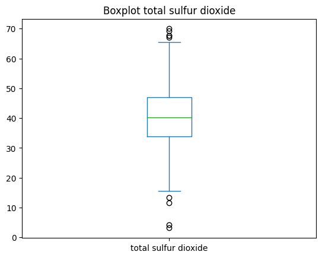

```python
kolom = "total sulfur dioxide"
data = df[kolom]
miu_0 = 35
alpha = 0.05
x_bar = data.mean()
std = data.std()
n = len(data)
root_n = np.sqrt(len(data))
z_alpha = st.norm.ppf(1 - alpha /2)
z = (x_bar - miu_0) / (std / root_n)
p_value = 1-abs(st.norm.cdf(z)-st.norm.cdf(-1*z))

display(Markdown(f"1. $H_0$:  $μ = {miu_0}$"))
display(Markdown(f"2. $H_1$:  $μ < {miu_0}$"))
display(Markdown(f"3. $\\alpha = 0.05$"))
display(Markdown("4. Uji Statistik:  $ z =\\frac{\\bar{x_{}} - μ_{0}} {\\sigma/\\sqrt{n}} $"))
display(Markdown(f"Daerah kritis: $z < z_\\alpha$"))
display(Markdown(f"Jika $z$ berada pada *critical section* ($z < z_\\alpha$), maka nilai $p > \\alpha$ dan $H_0$ ditolak"))
display(Markdown(f"Jika $z$ tidak berada pada *critical section* ($z ≥ z_\\alpha$), maka nilai $p ≤ \\alpha$ dan $H_0$ diterima"))

display(Markdown(f"""5. Komputasi<br>  $n = {n}$ <br>
$\\bar x$ = ${round(x_bar, 4)}$ <br> $\\sigma $ = ${round(std, 4)}$
<br> $z = {round(z, 4)}$<br> $z_\\alpha$ = ${round(z_alpha, 4)}$
<br> $p = {round(p_value, 7)}$<br> """))
display(Markdown(f"6. Test daerah kritis: "))
if z < z_alpha:
    display(Markdown(f"Keputusan: Tolak $H_0$ karena $z < z_\\alpha$"))
    display(Markdown(f"Tes Signifikan: Tolak $H_0$ karena $p$ lebih kecil dari tingkat signifikan ($p >= {alpha}$)"))
    display(Markdown(f"Maka, nilai rata-rata {kolom} kurang dari ${miu_0}$"))
else:
    display(Markdown(f"Keputusan: Tidak menolak $H_0$ karena $z ≥ z_\\alpha$" ))
    display(Markdown(f"Tes Signifikan: Terima $H_0$ dikarenakan $p$ lebih besar atau sama dengan tingkat signifikan ($p < {alpha}$)"))
    display(Markdown(f"Maka, nilai rata-rata {kolom} sama dengan ${miu_0}$"))

df[kolom].plot(kind="box")
plt.title(f"Boxplot {kolom}")
plt.show()
```

##### 4.e Proporsi nilai total sulfur dioxide yang lebih dari 40, adalah tidak sama dengan 50% ?

1. $H_0$: $p = 0.5$

2. $H_1$: $p ≠ 0.5$

3. $\alpha = 0.05$

4. Uji Statistik: $ z = \frac{\hat{p} - p_{0}} {\sqrt{p_{0}q_{0}/n}} $

Daerah kritis: $z > z_{\alpha/2}$ atau $z < -z_{\alpha/2}$

Jika $z$ berada pada *critical section* ( z > $z_{\alpha/2}$ atau $z < -z_{\alpha/2}$), maka nilai $p < \alpha$ dan $H_0$ ditolak

Jika $z$ tidak berada pada *critical section*, maka nilai $p ≥ \alpha$ dan $H_0$ diterima

5. Komputasi  
   $n = 512$

$\bar x$ = $40.2902$  
$\sigma $ = $9.9658$  
$z = 0.7592$  
$z_\alpha$ = $1.96$  
$p = 0.4477537$

6. Test daerah kritis:

Keputusan: Tidak menolak $H_0$ karena $z ≤ z_{\alpha/2}$ atau $z ≥ -z_{\alpha/2}$

Tes Signifikan: Terima $H_0$ dikarenakan $p$ lebih besar atau sama dengan tingkat signifikan ($p ≥ 0.05$)

Maka, proprosi nilai total total sulfur dioxide yang lebih dari 40 sama dengan $0.5$

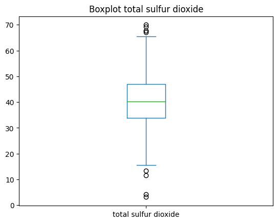

```python
kolom = "total sulfur dioxide"
data = df[kolom]
p_0 = 0.5
alpha = 0.05
x_bar = data.mean()
std = data.std()
N = len(data)
n = len(data[df[kolom] > 40])
root_n = np.sqrt(len(data))
z_alpha = st.norm.ppf(1 - alpha /2)

z, p_value = proportions_ztest(n, N, p_0)

display(Markdown(f"1. $H_0$:  $p = {p_0}$"))
display(Markdown(f"2. $H_1$:  $p ≠ {p_0}$"))
display(Markdown(f"3. $\\alpha = 0.05$"))
display(Markdown("4. Uji Statistik:  $ z = \\frac{\\hat{p} - p_{0}} {\\sqrt{p_{0}q_{0}/n}} $"))
display(Markdown("Daerah kritis: $z > z_{\\alpha/2}$ atau $z < -z_{\\alpha/2}$"))
display(Markdown("Jika $z$ berada pada *critical section* ( z > $z_{\\alpha/2}$ atau $z < -z_{\\alpha/2}$), maka nilai $p < \\alpha$ dan $H_0$ ditolak"))
display(Markdown(f"Jika $z$ tidak berada pada *critical section*, maka nilai $p ≥ \\alpha$ dan $H_0$ diterima"))

display(Markdown(f"""5. Komputasi<br>  $n = {n}$ <br>
$\\bar x$ = ${round(x_bar, 4)}$ <br> $\\sigma $ = ${round(std, 4)}$
<br> $z = {round(z, 4)}$<br> $z_\\alpha$ = ${round(z_alpha, 4)}$
<br> $p = {round(p_value, 7)}$<br> """))
display(Markdown(f"6.  Test daerah kritis: "))

if z > z_alpha or z < -z_alpha:
    display(Markdown("Keputusan: Tolak $H_0$ karena $z > z_{\\alpha/2}$ atau $z < -z_{\\alpha/2}$ "))
    display(Markdown(f"Tes Signifikan: Tolak $H_0$ karena $p$ lebih kecil dari tingkat signifikan ($p < {alpha}$)"))
    display(Markdown(f"Maka, proprosi nilai total {kolom} yang lebih dari 40 tidak sama dengan ${p_0}$"))
else:
    display(Markdown("Keputusan: Tidak menolak $H_0$ karena $z ≤ z_{\\alpha/2}$ atau $z ≥ -z_{\\alpha/2}$" ))
    display(Markdown(f"Tes Signifikan: Terima $H_0$ dikarenakan $p$ lebih besar atau sama dengan tingkat signifikan ($p ≥ {alpha}$)"))
    display(Markdown(f"Maka, proprosi nilai total {kolom} yang lebih dari 40 sama dengan ${p_0}$"))

df[kolom].plot(kind="box")
plt.title(f"Boxplot {kolom}")
plt.show()
```

##### 5. Melakukan test hipotesis 2 sampel,

##### 5.a Data kolom fixed acidity dibagi 2 sama rata: bagian awal dan bagian akhir kolom. Benarkah rata-rata kedua bagian tersebut sama?

1. $H_0$: $μ_1 - μ_2 = 0$

2. $H_1$: $μ_1 - μ_2 ≠ 0$

3. $\alpha = 0.05$

4. Uji Statistik: $ z = \frac{(\bar{x_{1}} - \bar{x_{2}}) - (μ_{1} - μ_{2})} {\sqrt{\sigma_{1}^{2}/n_{1} + \sigma_{2}^{2}/n_{2}}}$

Daerah kritis: $z > z_{\alpha/2}$ atau $z < -z_{\alpha/2}$

Jika $z$ berada pada *critical section* ( z > $z_{\alpha/2}$ atau $z < -z_{\alpha/2}$), maka nilai $p < \alpha$ dan $H_0$ ditolak

Jika $z$ tidak berada pada *critical section*, maka nilai $p ≥ \alpha$ dan $H_0$ diterima

5. Komputasi  
   n total $ = 1000$

$\bar x_1$ = $7.1535$  
$\sigma_1 $ = $1.2049$  
$\bar x_2$ = $7.1515$  
$\sigma_2 $ = $1.1995$  
$z = 0.026$  
$z_\alpha$ = $1.96$  
$p = 0.9792246$

6. Test daerah kritis:

Keputusan: Tidak menolak $H_0$ karena $z ≤ z_{\alpha/2}$ atau $z ≥ -z_{\alpha/2}$

Tes Signifikan: Terima $H_0$ dikarenakan $p$ lebih besar atau sama dengan tingkat signifikan ($p ≥ 0.05$)

Maka, rata-rata kedua bagian sama

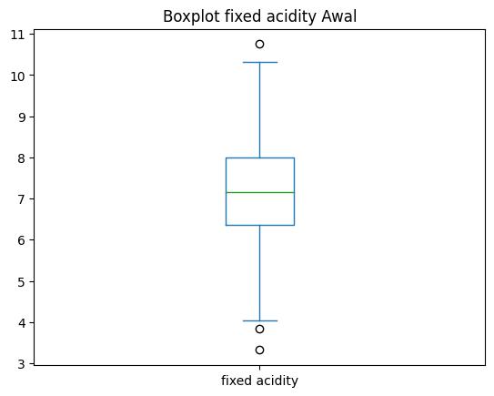

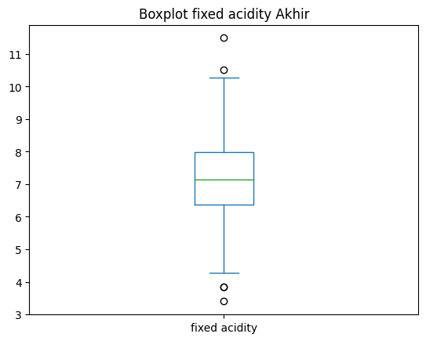

```python
kolom = "fixed acidity"
miu_0 = 0
alpha = 0.05
n = len(df)
awal = df[kolom][:n//2]
akhir = df[kolom][n//2:]
x_bar1 = awal.mean()
x_bar2 = akhir.mean()
std1 = awal.std()
std2 = akhir.std()

z, p_value = ztest(awal, akhir, value=miu_0, alternative="two-sided")

z_alpha = st.norm.ppf(1 - (alpha /2))

display(Markdown(f"1. $H_0$:  $μ_1 - μ_2 = {miu_0}$"))
display(Markdown(f"2. $H_1$:  $μ_1 - μ_2 ≠ {miu_0}$"))
display(Markdown(f"3. $\\alpha = 0.05$"))
display(Markdown("4. Uji Statistik: $ z = \\frac{(\\bar{x_{1}} - \\bar{x_{2}}) - (μ_{1} - μ_{2})} {\\sqrt{\\sigma_{1}^{2}/n_{1} + \\sigma_{2}^{2}/n_{2}}}$"))
display(Markdown("Daerah kritis: $z > z_{\\alpha/2}$ atau $z < -z_{\\alpha/2}$"))
display(Markdown("Jika $z$ berada pada *critical section* ( z > $z_{\\alpha/2}$ atau $z < -z_{\\alpha/2}$), maka nilai $p < \\alpha$ dan $H_0$ ditolak"))
display(Markdown(f"Jika $z$ tidak berada pada *critical section*, maka nilai $p ≥ \\alpha$ dan $H_0$ diterima"))

display(Markdown(f"""5. Komputasi<br>  n total $ = {n}$ <br>
$\\bar x_1$ = ${round(x_bar1, 4)}$ <br> $\\sigma_1 $ = ${round(std1, 4)}$
<br> $\\bar x_2$ = ${round(x_bar2, 4)}$ <br> $\\sigma_2 $ = ${round(std2, 4)}$
<br> $z = {round(z, 4)}$<br> $z_\\alpha$ = ${round(z_alpha, 4)}$
<br> $p = {round(p_value, 7)}$<br> """))

display(Markdown(f"6. Test daerah kritis: "))
if z > z_alpha or z < -z_alpha:
    display(Markdown("Keputusan: Tolak $H_0$ karena $z > z_{\\alpha/2}$ atau $z < -z_{\\alpha/2}$ "))
    display(Markdown(f"Tes Signifikan: Tolak $H_0$ karena $p$ lebih kecil dari tingkat signifikan ($p < {alpha}$)"))
    display(Markdown(f"Maka, rata-rata kedua bagian tidak sama"))
else:
    display(Markdown("Keputusan: Tidak menolak $H_0$ karena $z ≤ z_{\\alpha/2}$ atau $z ≥ -z_{\\alpha/2}$" ))
    display(Markdown(f"Tes Signifikan: Terima $H_0$ dikarenakan $p$ lebih besar atau sama dengan tingkat signifikan ($p ≥ {alpha}$)"))
    display(Markdown(f"Maka, rata-rata kedua bagian sama"))

awal.plot(kind="box")
plt.title(f"Boxplot {kolom} Awal")
plt.show()

akhir.plot(kind="box")
plt.title(f"Boxplot {kolom} Akhir")
plt.show()
```

##### 5.b Data kolom chlorides dibagi 2 sama rata: bagian awal dan bagian akhir kolom. Benarkah rata-rata bagian awal lebih besar daripada bagian akhir sebesar 0.001?

1. $H_0$: $μ_1 - μ_2 = 0.001$

2. $H_1$: $μ_1 - μ_2 ≠ 0.001$

3. $\alpha = 0.05$

4. Uji Statistik: $ z = \frac{(\bar{x_{1}} - \bar{x_{2}}) - (μ_{1} - μ_{2})} {\sqrt{\sigma_{1}^{2}/n_{1} + \sigma_{2}^{2}/n_{2}}}$

Daerah kritis: $z > z_{\alpha/2}$ atau $z < -z_{\alpha/2}$

Jika $z$ berada pada *critical section* ( z > $z_{\alpha/2}$ atau $z < -z_{\alpha/2}$), maka nilai $p < \alpha$ dan $H_0$ ditolak

Jika $z$ tidak berada pada *critical section*, maka nilai $p ≥ \alpha$ dan $H_0$ diterima

5. Komputasi  
   n total $ = 1000$

$\bar x_1$ = $0.0814$  
$\sigma_1 $ = $0.0202$  
$\bar x_2$ = $0.081$  
$\sigma_2 $ = $0.0201$  
$z = -0.4673$  
$z_\alpha$ = $1.96$  
$p = 0.640273$

6. Test daerah kritis:

Keputusan: Tidak menolak $H_0$ karena $z ≤ z_{\alpha/2}$ atau $z ≥ -z_{\alpha/2}$

Tes Signifikan: Terima $H_0$ dikarenakan $p$ lebih besar atau sama dengan tingkat signifikan ($p ≥ 0.05$)

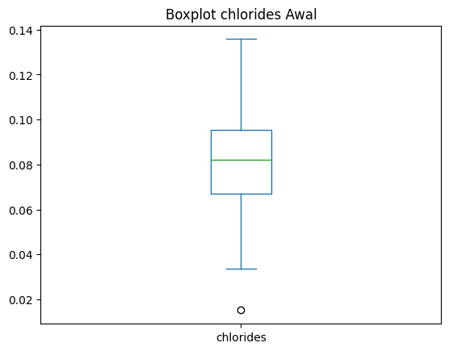

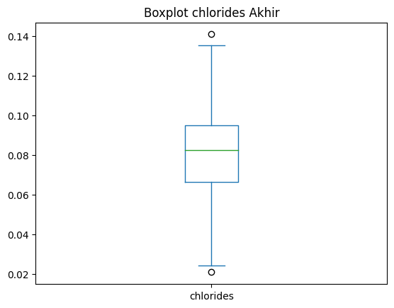

```python
kolom = "chlorides"
miu_0 = 0.001
alpha = 0.05
N = len(df)
awal = df[kolom][:N//2]
akhir = df[kolom][N//2:]
x_bar1 = awal.mean()
x_bar2 = akhir.mean()
std1 = awal.std()
std2 = akhir.std()

z, p_value = ztest(awal, akhir, value=miu_0, alternative="two-sided")

z_alpha = st.norm.ppf(1 - (alpha /2))

display(Markdown(f"1. $H_0$:  $μ_1 - μ_2 = {miu_0}$"))
display(Markdown(f"2. $H_1$:  $μ_1 - μ_2 ≠ {miu_0}$"))
display(Markdown(f"3. $\\alpha = 0.05$"))
display(Markdown("4. Uji Statistik: $ z = \\frac{(\\bar{x_{1}} - \\bar{x_{2}}) - (μ_{1} - μ_{2})} {\\sqrt{\\sigma_{1}^{2}/n_{1} + \\sigma_{2}^{2}/n_{2}}}$"))
display(Markdown("Daerah kritis: $z > z_{\\alpha/2}$ atau $z < -z_{\\alpha/2}$"))
display(Markdown("Jika $z$ berada pada *critical section* ( z > $z_{\\alpha/2}$ atau $z < -z_{\\alpha/2}$), maka nilai $p < \\alpha$ dan $H_0$ ditolak"))
display(Markdown(f"Jika $z$ tidak berada pada *critical section*, maka nilai $p ≥ \\alpha$ dan $H_0$ diterima"))

display(Markdown(f"""5. Komputasi<br>  n total $ = {n}$ <br>
$\\bar x_1$ = ${round(x_bar1, 4)}$ <br> $\\sigma_1 $ = ${round(std1, 4)}$
<br> $\\bar x_2$ = ${round(x_bar2, 4)}$ <br> $\\sigma_2 $ = ${round(std2, 4)}$
<br> $z = {round(z, 4)}$<br> $z_\\alpha$ = ${round(z_alpha, 4)}$
<br> $p = {round(p_value, 7)}$<br> """))

display(Markdown(f"6. Test daerah kritis: "))
if z > z_alpha or z < -z_alpha:
    display(Markdown("Keputusan: Tolak $H_0$ karena $z > z_{\\alpha/2}$ atau $z < -z_{\\alpha/2}$ "))
    display(Markdown(f"Tes Signifikan: Tolak $H_0$ karena $p$ lebih kecil dari tingkat signifikan ($p < {alpha}$)"))
    display(Markdown(f"Maka, rata-rata selisih bagian awal dengan bagian akhir tidak lebih besar dari {miu_0}"))
else:
    display(Markdown("Keputusan: Tidak menolak $H_0$ karena $z ≤ z_{\\alpha/2}$ atau $z ≥ -z_{\\alpha/2}$" ))
    display(Markdown(f"Tes Signifikan: Terima $H_0$ dikarenakan $p$ lebih besar atau sama dengan tingkat signifikan ($p ≥ {alpha}$)"))
    display(Markdown(f"Maka, rata-rata selisih bagian awal dengan bagian akhir tepat sebesar {miu_0}"))


awal.plot(kind="box")
plt.title(f"Boxplot {kolom} Awal")
plt.show()

akhir.plot(kind="box")
plt.title(f"Boxplot {kolom} Akhir")
plt.show()
```

Asumsi data bukan merupakan data sampel

1. $H_0$: $μ_1 - μ_2 = 0$

2. $H_1$: $μ_1 - μ_2 ≠ 0$

3. $\alpha = 0.05$

4. Uji Statistik: $ z = \frac{(\bar{x_{1}} - \bar{x_{2}}) - (μ_{1} - μ_{2})} {\sqrt{\sigma_{1}^{2}/n_{1} + \sigma_{2}^{2}/n_{2}}}$

Daerah kritis: $z > z_{\alpha/2}$ atau $z < -z_{\alpha/2}$

Jika $z$ berada pada *critical section* ( z > $z_{\alpha/2}$ atau $z < -z_{\alpha/2}$), maka nilai $p < \alpha$ dan $H_0$ ditolak

Jika $z$ tidak berada pada *critical section*, maka nilai $p ≥ \alpha$ dan $H_0$ diterima

$\bar x_1$ = $0.5014$  
$\sigma_1 $ = $0.0834$  
$\bar x_2$ = $0.6164$  
$\sigma_2 $ = $0.1171$  
$z = -3.9978$  
$z_\alpha$ = $1.96$  
$p = 6.39e-05$

6. Test daerah kritis:

Keputusan: Tolak $H_0$ karena $z > z_{\alpha/2}$ atau $z < -z_{\alpha/2}$

Tes Signifikan: Tolak $H_0$ karena $p$ lebih kecil dari tingkat signifikan ($p < 0.05$)

Maka, rata-rata volatile acidity tidak sama dengan sulphates

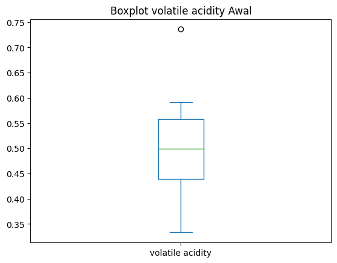

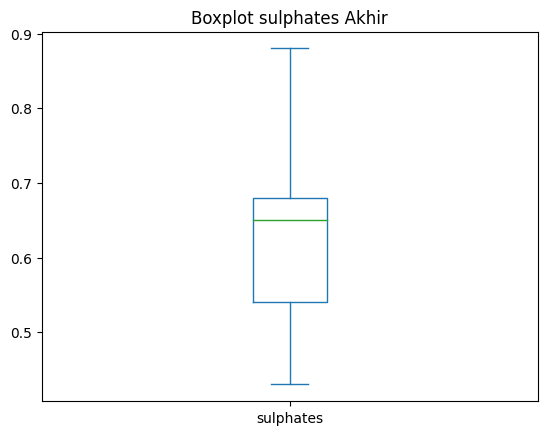

```python
kolom1 = "volatile acidity"
kolom2 = "sulphates"
miu_0 = 0
alpha = 0.05
awal = df[kolom1].head(25)
akhir = df[kolom2].tail(25)
x_bar1 = awal.mean()
x_bar2 = akhir.mean()
std1 = awal.std()
std2 = akhir.std()

z, p_value = ztest(awal, akhir, value=miu_0, alternative="two-sided")

z_alpha = st.norm.ppf(1 - (alpha /2))

display(Markdown(f"Asumsi data bukan merupakan data sampel"))
display(Markdown(f"1. $H_0$:  $μ_1 - μ_2 = {miu_0}$"))
display(Markdown(f"2. $H_1$:  $μ_1 - μ_2 ≠ {miu_0}$"))
display(Markdown(f"3. $\\alpha = 0.05$"))
display(Markdown("4. Uji Statistik: $ z = \\frac{(\\bar{x_{1}} - \\bar{x_{2}}) - (μ_{1} - μ_{2})} {\\sqrt{\\sigma_{1}^{2}/n_{1} + \\sigma_{2}^{2}/n_{2}}}$"))
display(Markdown("Daerah kritis: $z > z_{\\alpha/2}$ atau $z < -z_{\\alpha/2}$"))
display(Markdown("Jika $z$ berada pada *critical section* ( z > $z_{\\alpha/2}$ atau $z < -z_{\\alpha/2}$), maka nilai $p < \\alpha$ dan $H_0$ ditolak"))
display(Markdown(f"Jika $z$ tidak berada pada *critical section*, maka nilai $p ≥ \\alpha$ dan $H_0$ diterima"))

display(Markdown(f"""5. Komputasi<br>  n total $ = {n}$ <br>
$\\bar x_1$ = ${round(x_bar1, 4)}$ <br> $\\sigma_1 $ = ${round(std1, 4)}$
<br> $\\bar x_2$ = ${round(x_bar2, 4)}$ <br> $\\sigma_2 $ = ${round(std2, 4)}$
<br> $z = {round(z, 4)}$<br> $z_\\alpha$ = ${round(z_alpha, 4)}$
<br> $p = {round(p_value, 7)}$<br> """))

display(Markdown(f"6. Test daerah kritis: "))
if z > z_alpha or z < -z_alpha:
    display(Markdown("Keputusan: Tolak $H_0$ karena $z > z_{\\alpha/2}$ atau $z < -z_{\\alpha/2}$ "))
    display(Markdown(f"Tes Signifikan: Tolak $H_0$ karena $p$ lebih kecil dari tingkat signifikan ($p < {alpha}$)"))
    display(Markdown(f"Maka, rata-rata {kolom1} tidak sama dengan {kolom2}"))
else:
    display(Markdown("Keputusan: Tidak menolak $H_0$ karena $z ≤ z_{\\alpha/2}$ atau $z ≥ -z_{\\alpha/2}$" ))
    display(Markdown(f"Tes Signifikan: Terima $H_0$ dikarenakan $p$ lebih besar atau sama dengan tingkat signifikan ($p ≥ {alpha}$)"))
    display(Markdown(f"Maka, rata-rata {kolom1} sama dengan {kolom2}"))

awal.plot(kind="box")
plt.title(f"Boxplot {kolom1} Awal")
plt.show()

akhir.plot(kind="box")
plt.title(f"Boxplot {kolom2} Akhir")
plt.show()
```

##### 5.d Bagian awal kolom residual sugar memiliki variansi yang sama dengan bagian akhirnya?

1. $H_0$: $σ_1^2 = σ_2^2$

2. $H_1$: $σ_1^2 ≠ σ_2^2$

3. $\alpha = 0.05$

4. Uji Statistik: $ f =\frac{S_1^2} {S_2^2} $

Daerah kritis: $f < f_{1 - \alpha / 2} (v_1, v_2)$ atau $f > f_{\alpha / 2} (v_1, v_2)$

Jika $f$ berada pada *critical section* ($f < f_{1 - \alpha / 2} (v_1, v_2)$ atau $f > f_{\alpha / 2} (v_1, v_2)$), maka nilai $p < \alpha$ dan $H_0$ ditolak

Jika $f$ tidak berada pada *critical section* ($f ≥ f_{1 - \alpha / 2} (v_1, v_2)$ atau $f ≤ f_{\alpha / 2} (v_1, v_2)$), maka nilai $p ≥ \alpha$ dan $H_0$ diterima

5. Komputasi:  
   $f_{1 - \alpha / 2} (v_1, v_2) = 0.8389$  
   $f_{\alpha / 2} (v_1, v_2) = 1.1921$  
   $f = 0.942$  
   $p = 0.7476$

Keputusan: Tidak menolak $H_0$ karena $f$ tidak berada pada *critical section* ($ 0.8389 ≤ z ≤ 1.1921$)

Tes Signifikan: Tidak menolak $H_0$ karena $p ≥ 0.05$

Maka, variansi pada bagian awal kolom residual sugar sama dengan variansi pada bagian akhirnya

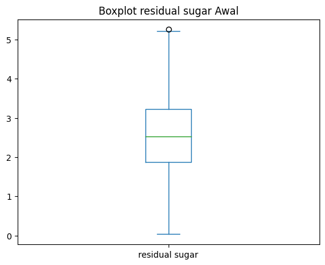

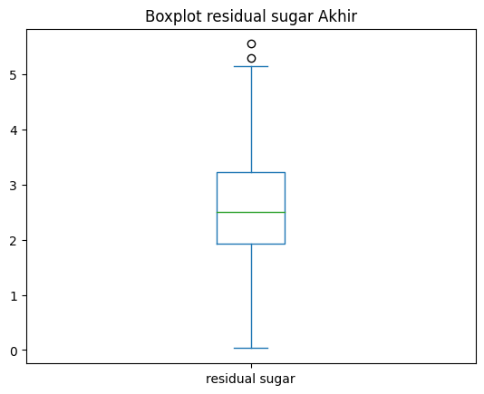

```python
kolom = "residual sugar"
alpha = 0.05

# v = n - 1
v_1 = len(df[:len(df) // 2]) - 1
v_2 = len(df[len(df) // 2:]) - 1

# Bagi data menjadi dua bagian
awal = df[kolom][:len(df) // 2]
akhir = df[kolom][len(df) // 2:]

# Uji statistik double sampe two tailed F test
f = awal.var() / akhir.var()
p = 1 - st.f.cdf(f, v_1, v_2)

# Daerah kritis
f_lower = st.f.ppf(alpha / 2, v_1, v_2)
f_upper = st.f.ppf(1 - alpha / 2, v_1, v_2)

display(Markdown("1. $H_0$:  $σ_1^2 = σ_2^2$"))
display(Markdown("2. $H_1$:  $σ_1^2 ≠ σ_2^2$"))
display(Markdown(f"3. $\\alpha = {alpha}$"))
display(Markdown("4. Uji Statistik:  $ f =\\frac{S_1^2} {S_2^2} $"))
display(Markdown(f"Daerah kritis: $f < f_{{1 - \\alpha / 2}} (v_1, v_2)$ atau $f > f_{{\\alpha / 2}} (v_1, v_2)$"))
display(Markdown(f"Jika $f$ berada pada *critical section* ($f < f_{{1 - \\alpha / 2}} (v_1, v_2)$ atau $f > f_{{\\alpha / 2}} (v_1, v_2)$), maka nilai $p < \\alpha$ dan $H_0$ ditolak"))
display(Markdown(f"Jika $f$ tidak berada pada *critical section* ($f ≥ f_{{1 - \\alpha / 2}} (v_1, v_2)$ atau $f ≤ f_{{\\alpha / 2}} (v_1, v_2)$), maka nilai $p ≥ \\alpha$ dan $H_0$ diterima"))


display(Markdown(f'''5. Komputasi: <br>
    $f_{{1 - \\alpha / 2}} (v_1, v_2) = {round(f_lower, 4)}$ <br>
    $f_{{\\alpha / 2}} (v_1, v_2) = {round(f_upper, 4)}$ <br>
    $f = {round(f, 4)}$ <br> $p = {round(p, 4)}$ <br>
'''))

if f < f_lower or f > f_upper:
    display(Markdown(f"Keputusan: Tolak $H_0$ karena $f$ berada pada *critical section* ($f < {round(f_lower, 4)}$ atau $f > {round(f_upper, 4)}$)"))
    display(Markdown(f"Tes Signifikan: Tolak $H_0$ karena $p < {alpha}$"))
    display(Markdown(f"Maka, variansi pada bagian awal kolom {kolom} tidak sama dengan variansi pada bagian akhirnya"))
else:
    display(Markdown(f"Keputusan: Tidak menolak $H_0$ karena $f$ tidak berada pada *critical section* ($ {round(f_lower, 4)} ≤ z ≤ {round(f_upper, 4)}$)"))
    display(Markdown(f"Tes Signifikan: Tidak menolak $H_0$ karena $p ≥ {alpha}$"))
    display(Markdown(f"Maka, variansi pada bagian awal kolom {kolom} sama dengan variansi pada bagian akhirnya"))

awal.plot(kind="box")
plt.title(f"Boxplot {kolom} Awal")
plt.show()

akhir.plot(kind="box")
plt.title(f"Boxplot {kolom} Akhir")
plt.show()
```

##### 5.e Proporsi nilai setengah bagian awal alcohol yang lebih dari 7, adalah lebih besar daripada, proporsi nilai yang sama di setengah bagian akhir alcohol?

```python
kolom = "alcohol"
delta_p = 0
alpha = 0.05
z_alpha = st.norm.ppf(1 - alpha)

# Bagi data menjadi dua bagian
awal = df.iloc[:len(df)//2]
akhir = df.iloc[len(df)//2:]

# Uji statistik single sample right tailed one propotion Z test
z_score, p_value = proportions_ztest([len(awal[awal[kolom] > 7]),
                                      len(akhir[akhir[kolom] > 7])],
                                     [len(awal), len(akhir)],
                                     value=delta_p, alternative='larger')

display(Markdown("1. $H_0$:  $p_1 - p_2 = 0$"))
display(Markdown("2. $H_1$:  $p_1 - p_2 > 0$"))
display(Markdown(f"3. $\\alpha = {alpha}$"))
display(Markdown("4. Uji Statistik:  $ z =\\frac{p_1 - p_2 - \\delta_p} {\\sqrt{\\frac{p_1 (1 - p_1)} {n_1} + \\frac{p_2 (1 - p_2)} {n_2}}} $"))
display(Markdown(f"Daerah kritis: $z > z_{{\\alpha}}$"))
display(Markdown(f"Jika $z$ berada pada *critical section* ($z > z_{{\\alpha}}$), maka nilai $p < \\alpha$ dan $H_0$ ditolak"))
display(Markdown(f"Jika $z$ tidak berada pada *critical section* ($z ≤ z_{{1 - \\alpha}}$), maka nilai $p ≥ \\alpha$ dan $H_0$ diterima"))
display(Markdown(f'''5. Komputasi: <br>
    $z_{{\\alpha}} = {round(z_alpha, 4)}$ <br>
    $z = {round(z_score, 4)}$ <br> $p = {round(p_value, 4)}$ <br>
'''))


if z_score > z_alpha:
    display(Markdown(f"Keputusan: Tolak $H_0$ karena $z$ berada pada *critical section* ($z > {round(z_alpha, 4)}$)"))
    display(Markdown(f"Tes Signifikan: Tolak $H_0$ karena $p < {alpha}$"))
    display(Markdown(f"Maka, proporsi nilai setengah bagian awal alcohol yang lebih dari 7, lebih besar daripada proporsi nilai yang sama di setengah bagian akhir"))
else:
    display(Markdown(f"Keputusan: Tidak menolak $H_0$ karena $z$ tidak berada pada *critical section* ($z ≤ {round(z_alpha, 4)}$)"))
    display(Markdown(f"Tes Signifikan: Tidak menolak $H_0$ karena $p ≥ {alpha}$"))
    display(Markdown(f"Maka, proporsi nilai setengah bagian awal alcohol yang lebih dari 7, sama besar daripada proporsi nilai yang sama  di setengah bagian akhir"))
```

1. $H_0$: $p_1 - p_2 = 0$

2. $H_1$: $p_1 - p_2 > 0$

3. $\alpha = 0.05$

4. Uji Statistik: $ z =\frac{p_1 - p_2 - \delta_p} {\sqrt{\frac{p_1 (1 - p_1)} {n_1} + \frac{p_2 (1 - p_2)} {n_2}}} $

Daerah kritis: $z > z_{\alpha}$

Jika $z$ berada pada *critical section* ($z > z_{\alpha}$), maka nilai $p < \alpha$ dan $H_0$ ditolak

Jika $z$ tidak berada pada *critical section* ($z ≤ z_{1 - \alpha}$), maka nilai $p ≥ \alpha$ dan $H_0$ diterima

5. Komputasi:  
   $z_{\alpha} = 1.6449$  
   $z = 0.0$  
   $p = 0.5$

Keputusan: Tidak menolak $H_0$ karena $z$ tidak berada pada *critical section* ($z ≤ 1.6449$)

Tes Signifikan: Tidak menolak $H_0$ karena $p ≥ 0.05$

Maka, proporsi nilai setengah bagian awal alcohol yang lebih dari 7, sama besar daripada proporsi nilai yang sama di setengah bagian akhir